# Collaborative Research: Spatial Distribution of Crime as a Function of the Demarcation of Police Power

Fabian Bohnenberger and Sebastian Martinez

November 20, 2015

## Summary

This research project shows the relationship between the spatial distribution of crimes and the allocation and demarcation of police power in the city of Chicago.

## Introduction

Every community deals with the presence of crime. Criminal activity has a multitude of causes and the origins of crime have been the subject of investigation by many disciplines. The organization of law enforcement’s response is a key factor in understanding the nature and extent of crime occurring in a specific area. For example, one city may be better at fighting crime, because it has correctly identified hotspots and distributed its police forces accordingly. This often includes setting up police stations in trouble zones or adjusting police district and beat boundaries to better allocate existing forces.

## Literature Overview and Relevance of Research

The origins of crime have been the subject of investigation by many disciplines. A significant amount of the literature has looked at socioeconomic conditions to explain the occurence of urban crime. J. R. Blau and Blau (1982), for example, finds that “socioecconomic inequality between races, as well as economic inequality generally, increases the rates of criminal violence”. Delbecq, Guillain, and Legros (2013), in their analysis of Chicago crime, see criminal activity “rooted in a lack or a weakening of social control exerted by communities because of poverty, residential instability and racial/ethnic heterogeneity”. However, an increasing amount of literature, for example Charron (2009), includes spatial characteristics of neighborhoods and districts, including urban structure, urbanisation levels, land/zone use, the presence of graffiti, garbage and run-down buildings, employment density, pollution, availability of public transport, and other variables in their analysis.

Some literature has looked primarily at the effects of a city’s spatial characteristics on crime. Described in a more conceptual manner, a city is not only set of objects placed one next to the other, but a set of places with specific functions designed for its citizens. The inhabitants interact with the physical space and vice versa; thus shaping both available actions as well as surrounding structure. For example, researchers have found that a denser, mixed used neighborhood has a smaller number of crime occurrences than a sprawled, more spread out neighborhood. Morenoff and Sampson (1997) specifically show that crime has a spatial component, often ignored by social researchers. They also argue that depending on the physical structure of a city, areas with high crime can spread out to neighboring areas in a process called “spatial diffusion of crime”. Further, Rosenfeld, Bray, and Egley (1999) found that when controlling for neighborhood demographic characteristics, the spatial distribution of crime is due to both the intrinsic characteristics of gang culture and the facilitating neighborhood characteristics. Leenders (2002), for example, builds on this research in his calculation of weights matrices to determine the use composition of a block, but also its relation with neighboring blocks, to allow for empirical research on the diffusion effects of crime.

Other research, especially criminological literature, focuses more on the operative part of crime prevention, but also heavily relies on the research on the effects of spatial characteristics. The “Broken Windows Theory” postulated by James Q. Wilson and George Kelling in 1982 in an influential article in the Atlantic Monthly represents an important starting point. Wilson and Kelling (1982) suggest that targeting minor disorder, e.g. vandalism, broken windows could help reduce more serious crime. The theory assumes that the landscape “communicates” to people. A broken window transmits to criminals the message that a community displays a lack of informal social control, and is therefore unable or unwilling to defend itself against a criminal invasion. In more recent literature, this theory is, however criticized for its simplicity. Acccording to Harcourt and Ludwig (2006), evidence from New York City crime data and from social experiments in five US cities would “provide no support for a simple first-order disorder-crime relationship as hypothesized by Wilson and Kelling, nor for the proposition that broken windows policing is the optimal use of scarce law enforcement resources.”

While urban hotspots of crime are often well documented, there has been, according to Zipkin, Short, and Bertozzi (2014), only limited research on “optimal and dynamically adapting police responses to changing crime patterns”. By looking at the the City of Chicago’s data, we aim to contribute to the research that tries to understand optimal police responses both on the operative as well as on the organizational level.

## Research Question / Hypotheses

Our research aims to show the relationship between the spatial distribution of crimes and the allocation and demarcation of police power in the city of Chicago. We operationalize the concept of “demarcation of police power” in two ways: First, we measure the distance between crime scenes and the physical location of the police station. Second, we measure the distance between the crime scene and the calculated center of the district. This provides an approximation of the distance of the crime to the district border, which is otherwise difficult and hardware-intensive to calculate. The motivation for this research stems from the way a city is divided into organizational districts, invisible to pedestrians, but potentially limiting in the way police can effectively carry out their duty.

### Research Question

Our key research question is: *Does the physical location of police stations and the organizational demarcation of police districts have a statistically significant effect on the spatial distribution of crime in the city of Chicago?*

### Hypotheses

The proposed research questions are connected to the following hypotheses:

**Hyptohesis 1**: The farther away from the police station, the more crimes are committed.

**Hypothesis 2**: An overall rising number of crimes means crime moves closer to the police station.

**Hypothesis 3**: Specific crimes are mostly perpetrated near the district borders; their chance to occur closer to police stations is low.

## Methodology

The proposed methodology is to run a regression using the *relative* position of a crime against the specific characteristics of the police district and the type of crime as independent variables. The idea behind this is that depending on the active presence of police in a district, criminals might have incentives to move further away from the places where the police have a more sound presence. In other words, this research is trying to explain the development of crime hotspots in relation to the organizational distribution of responsibility to specific police forces in a city. The data sources, as well as the necessary transformations are described in this chapter.

## Data Collection

The main source for accessing data for this research project is the Data Portal of the City of Chicago. The website provides access to government data on the City departments, services, facilities and performance and also allows access via an API. The [Socrata Open Data API](https://github.com/chicago) can be used to load the data directly into R. To import the information, we rely on R’s “Rio” package, which features the “import” function.

### Overview of data used in this project

1. Crime Data (available 2001 to present)

This [dataset on crime in Chicago](https://data.cityofchicago.org/Public-Safety/Crimes-2001-to-present/ijzp-q8t2) includes information on all crimes that were reported in the city from 2001 until 2015. It includes the date and time, the “primary type” of the crime (e.g. theft, arson, narcotics), a short description (e.g. type of weapon used, broad indication of the value stolen), and whether there has been an arrest. Additionally, it provides us with detailed data on the location of the crime, including latitude and longitude as well as in which police beat and district and in which community district the crime occurred. It also includes a specific location description (e.g. sidewalk, office building or school).

2. District and community border data

For our research project, information on borders of police districts and “communities” is crucial. Information on [police districts](https://data.cityofchicago.org/Public-Safety/Boundaries-Police-Districts-current-/fthy-xz3r) is important because we are interested in the spatial distribution of crime as a function of the location of police stations and the organizational delineation of police power. [Community borders](https://data.cityofchicago.org/Facilities-Geographic-Boundaries/Boundaries-Community-Areas-current-/cauq-8yn6) are important because most socioeconomic data available on the Chicago Data Portal is aggregated on the community level. This does also include information on age distributions, health, as well as organizational statistics like abandoned buildings, land use and energy consumption.

3. Control variables (including socioeconomic data, esp. 2008-2012)

We rely on a regression to explain the occurence of crime at specific locations as a function of the spatial allocation of police force in a city. Our dependent variable is the occurence of specific crimes. Independent variables are the distance to the main and support police stations as well as the distance to the center of the police district. For the regression, we have to control for the specific characteristics of the police districts in question that affect crime. Economic and demographic factors in each city area (community level data) must be considered, as well as other imortant variables. The City of Chicago Data Portal offers information on the following characteristics of communities:

- [Census Data 2008-2012](https://data.cityofchicago.org/Health-Human-Services/Census-Data-Selected-socioeconomic-indicators-in-C/kn9c-c2s2), especially focusing on certain socioeconomic indicators (percent of housing crowded, percent households below poverty line, percentage aged 16+ unemployed, percentage aged 25+ without highschool diploma, percentage aged under 18 or over 64, per capita income, and a weighted “hardship index”. Further explanation on the dataset can be accessed here
- Additional information on the community level can be found in this [public health statistics dataset](https://data.cityofchicago.org/Health-Human-Services/Public-Health-Statistics-Selected-public-health-in/iqnk-2tcu), which not only provides information on birth rates and a number of diseases, but also lists environment or poverty-related diseases (e.g. childhood lead poisoning), the teen birth rate and includes data on unemployment levels on the community level. This [dataset](https://data.cityofchicago.org/Health-Human-Services/Public-Health-Statistics-Life-Expectancy-By-Commun/qjr3-bm53) provides additional information on the life expectancy on the community level. Additionally, the Data Portal includes relevant [data](https://data.cityofchicago.org/Community-Economic-Development/Vacant-Properties-by-Community-Area/cjr7-qyw5) like the number of vacant properties on the community level.
- Other datasets on the community level are: Data on [energy use](https://data.cityofchicago.org/Environment-Sustainable-Development/Average-Electricity-Usage-per-Square-Foot-by-Commu/usfg-z9mx) and data on [special empowerment zones](https://data.cityofchicago.org/Community-Economic-Development/Boundaries-Empowerment-Zones/m6ef-sjkj) across districts.
- The City of Chicago also offers information on police funding over the years on a district level. It is, however, not easily discernible whether year-to-year budget changes are actually funding active police work or are, for example, neccessary to cover pensions. Also, the allocation of funding to specific districts cannot be fully ascertained based on the provided data.
- There are, however, some factors that are not readily measurable or for which no data exists and we need to make indirect assumptions (e.g. citizens attitude towards crime, crime reporting practices of the citizenry, family cohesiveness, cultural characteristics) FBI (2015) offers a comprehensive list of factors that are known to affect the volume and type of crime.

### Data collection

Data is collected using R’s “Rio” package. Alternatively, one can also rely on the City of Chicago Data Portal’s recommended “RSocrata” package.

### Calculating District Centers

As described above, an important first step for our analysis is the calulcation of th police district centers. This provides us with an approximation of the distance of each crime to the district border. In addition, we prepare the data on the location of police stations.

**Figure 1** shows a plot with the map of Chicago. It is divided into Police Districts, the centroids of every district are presented in circles. The locations of all the police stations is presented in triangles.

**Figure 1**

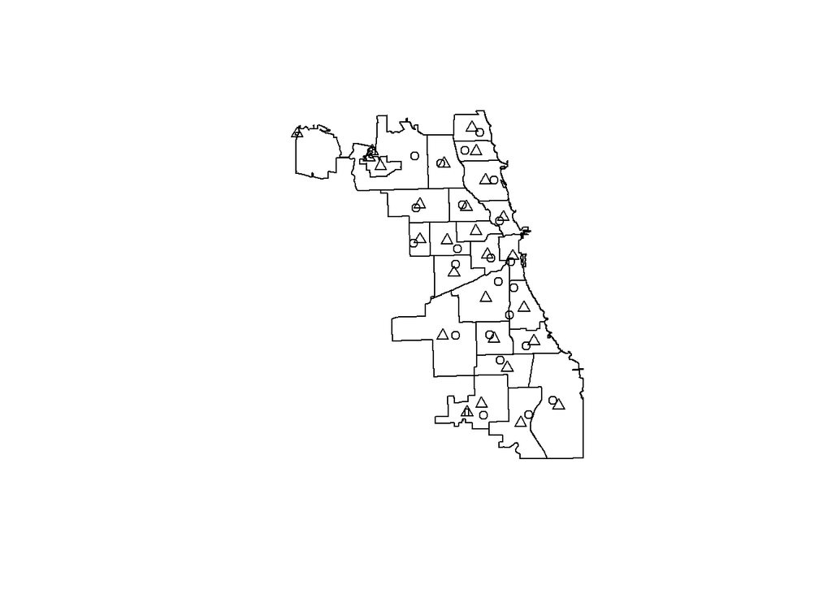

Second, we have to compare the police districts with the delineation of “communities” in Chicago. This is important because the socioeconomic data that will be used in our regression is based on this aggregation level. As **Figure 2** shows, the Community Districts are different from the Police Districts. The figure also includes the respective community districts. We will therefore have to be careful in our following analysis to link each crime with the relevant socioeconomic information depending on in which community, not police district, it is committed.

**Figure 2**

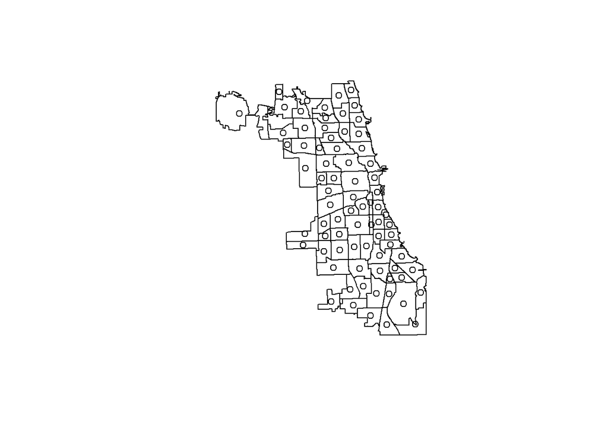

### Merging the Data

To connect the datasets mentioned above and include the relevant information on district centers, we merge the relevant data in a two step process. First, the crime and census data are merged based on the “community area” code that is used in both datasets. Second, the data on police districts and community areas with their respective centroids is merged with the crime and census data.

## Calculating the distance of crimes

To determine which crimes occur closer to the border of each district, and hence farther away from the location of the police station for that district, we calculate two distances: First, based on our calculations of the police district centers, we estimate the distance between the location of each crime and the center of the police district. Second, we determine the distance between the crime scene and the police station.

We calculate both distances in two ways:

1. The absolute distance of each crime to the district’s center.
2. The relative distance based on the crime in each district that is farthest away from the district’s center. The relative distance is calculated as the distance of every crime to the center divided by the distance of the crime that is the farthest away from the center of the district. This allows us to understand the position of every crime in relation to the police district where it occurred, instead of a level measurement.

## Descriptive statistics

This section is used to describe the data on which our analysis is based and present trends and interesting cases on an aggregated (across districts) and disaggregated level. We also test the explanatory value of the *relative* distance calculation in this section.

### Aggregate Crime Statistics

**Table 1** shows the types of crimes included in the City of Chicago dataset with the respective number of reported instances for the year 2012. The table presents the data for all districts and all crime types. It is important that a some categories contain very few observations. Therefore, any inferences based on these categories will neccessarily be less statistically significant. We omit these categories in the inferential part of our analysis.

Table 1 - Number of Reported Crimes (All Districts, All Crime Types)

|  | distance_from_border_type | distance_from_border_number |
| --- | --- | --- |
| 17 | NON-CRIMINAL | 4 |
| 24 | PUBLIC INDECENCY | 6 |
| 1 | ARSON | 155 |
| 26 | ROBBERY | 3791 |
| 28 | STALKING | 89 |
| 20 | OFFENSE INVOLVING CHILDREN | 669 |
| 2 | ASSAULT | 5624 |
| 9 | GAMBLING | 186 |
| 11 | INTERFERENCE WITH PUBLIC OFFICER | 381 |
| 4 | BURGLARY | 8590 |
| 30 | WEAPONS VIOLATION | 722 |
| 16 | NARCOTICS | 9729 |
| 14 | LIQUOR LAW VIOLATION | 260 |
| 8 | DECEPTIVE PRACTICE | 4976 |
| 3 | BATTERY | 17762 |
| 25 | PUBLIC PEACE VIOLATION | 800 |
| 22 | OTHER OFFENSE | 6080 |
| 6 | CRIMINAL DAMAGE | 12441 |
| 7 | CRIMINAL TRESPASS | 2674 |
| 29 | THEFT | 31813 |
| 15 | MOTOR VEHICLE THEFT | 6329 |
| 13 | KIDNAPPING | 100 |
| 21 | OTHER NARCOTIC VIOLATION | 4 |
| 10 | HOMICIDE | 97 |
| 5 | CRIM SEXUAL ASSAULT | 429 |
| 23 | PROSTITUTION | 610 |
| 12 | INTIMIDATION | 51 |
| 27 | SEX OFFENSE | 405 |
| 19 | OBSCENITY | 12 |
| 18 | NON-CRIMINAL (SUBJECT SPECIFIED) | 1 |

**Table 2** presents the *relative* distance between crime scene and police station as well as the *relative* distance between crime scene and the calculated police district center. The table again shows all crime types and presents the average across all districts.

Table 2 - Relative Distance to Policy Station and to District Center (Accross All Districts, All Crime Types)

|  | distance_from_border_type | distance_from_border | distance_to_station_type | distance_to_station |
| --- | --- | --- | --- | --- |
| 17 | NON-CRIMINAL | 0.1992823 | NON-CRIMINAL | 0.1797227 |
| 24 | PUBLIC INDECENCY | 0.2867640 | STALKING | 0.2642918 |
| 1 | ARSON | 0.3336800 | KIDNAPPING | 0.2671208 |
| 26 | ROBBERY | 0.3395320 | ARSON | 0.2731567 |
| 28 | STALKING | 0.3470012 | INTIMIDATION | 0.2802519 |
| 20 | OFFENSE INVOLVING CHILDREN | 0.3479447 | WEAPONS VIOLATION | 0.2843409 |
| 2 | ASSAULT | 0.3512491 | PUBLIC INDECENCY | 0.2859850 |
| 9 | GAMBLING | 0.3523917 | LIQUOR LAW VIOLATION | 0.2861885 |
| 11 | INTERFERENCE WITH PUBLIC OFFICER | 0.3525415 | NARCOTICS | 0.2870246 |
| 4 | BURGLARY | 0.3526330 | ROBBERY | 0.2870849 |
| 30 | WEAPONS VIOLATION | 0.3526452 | DECEPTIVE PRACTICE | 0.2876967 |
| 16 | NARCOTICS | 0.3532451 | OFFENSE INVOLVING CHILDREN | 0.2879786 |
| 14 | LIQUOR LAW VIOLATION | 0.3532709 | INTERFERENCE WITH PUBLIC OFFICER | 0.2885912 |
| 8 | DECEPTIVE PRACTICE | 0.3538001 | ASSAULT | 0.2901299 |
| 3 | BATTERY | 0.3555843 | BATTERY | 0.2915579 |
| 25 | PUBLIC PEACE VIOLATION | 0.3589989 | OTHER OFFENSE | 0.2928438 |
| 22 | OTHER OFFENSE | 0.3596853 | BURGLARY | 0.2940290 |
| 6 | CRIMINAL DAMAGE | 0.3597468 | CRIMINAL TRESPASS | 0.2940489 |
| 7 | CRIMINAL TRESPASS | 0.3621227 | PUBLIC PEACE VIOLATION | 0.2943171 |
| 29 | THEFT | 0.3649994 | CRIMINAL DAMAGE | 0.2953775 |
| 15 | MOTOR VEHICLE THEFT | 0.3652571 | MOTOR VEHICLE THEFT | 0.2990385 |
| 13 | KIDNAPPING | 0.3661075 | THEFT | 0.3027394 |
| 21 | OTHER NARCOTIC VIOLATION | 0.3678643 | SEX OFFENSE | 0.3038116 |
| 10 | HOMICIDE | 0.3696138 | CRIM SEXUAL ASSAULT | 0.3053200 |
| 5 | CRIM SEXUAL ASSAULT | 0.3708573 | HOMICIDE | 0.3069019 |
| 23 | PROSTITUTION | 0.3747230 | PROSTITUTION | 0.3268022 |
| 12 | INTIMIDATION | 0.3797288 | OBSCENITY | 0.3368920 |
| 27 | SEX OFFENSE | 0.3812722 | GAMBLING | 0.3391393 |
| 19 | OBSCENITY | 0.3852943 | NON-CRIMINAL (SUBJECT SPECIFIED) | 0.3724863 |
| 18 | NON-CRIMINAL (SUBJECT SPECIFIED) | 0.6165038 | OTHER NARCOTIC VIOLATION | 0.4504676 |

As shown in **Table 2**, the *relative* distances in both columns are not the same, but lead to overall similar results. Differences occur because the police station is not always located at the center of the district, as it is calculated in this analysis.

### Disaggregated Crime Statistics

As **Figure 3** shows, the relative distance for crime types across all districts is not significantly distributed to make inferences about the occurence of specific crimes. We need to look at more disaggregated data to find differences in the spatial distribution of crime.

**Figure 3 - Relative Distance between Crime Types and District Center across Police Districts**

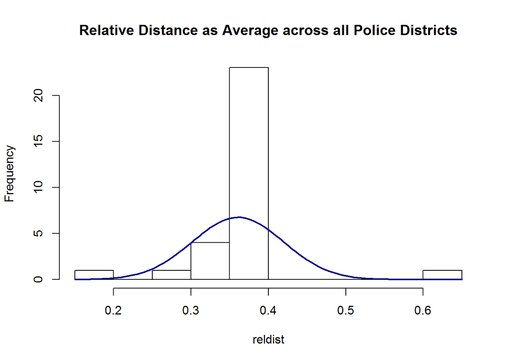

As we can see in **Figure 4**, looking at the data for each crime type and district separately leads to significant improvements. The figure includes all calculated average distances that were calculated on a district-by-district basis. We will have to assess differences in the spatial distribution of crime (in terms of distance from the police district center) for each district in a next step.

**Figure 4 - Relative Distance between Crime Types and District Center for individual Police Districts**

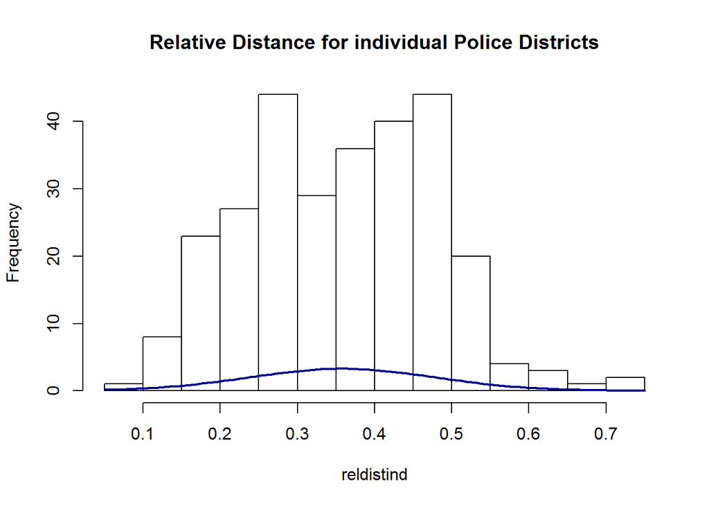

**Figure 5 - Example District**

[figure not shown]